# pmhc_denoiseR vignette

Grigorii Nos

2024-03-14

## R Markdown

pmhcDenoiseR is a data denoising workflow for single-cell pMHC datasets. The workflow also assigns the pMHC specificities to individual clonotypes. pmhcDenoiseR works with coupled single-cell pMHC counts with TCR clonotypes.

```r
library(Seurat)
library(pmhcDenoiseR)
library(uniformly)
library(tidyverse)
```

```r
library(ggplot2)
library(ComplexHeatmap)
```

### load the data

we generated a dataset with PBMC T cells from healthy donors, that were screen for the recognition 100 pMHC panel of common chronic viral epitopes, the data is stored as a Seurat object, as the whole package is build around Seurat class

```
## 6 x 8141 sparse Matrix of class "dgCMatrix"
```

```
##   [[ suppressing 8141 column names '1OS_AAACCTGAGCCAGTTT', '1OS_AAACCTGAGGCGCTCT', '1OS_AAACCTGAGTCCTCCT' ... ]]
```

[output not shown]

[output cut: 1625 more lines]

[output not shown]

the gene expression part of this object is deleted here to save the space, in case you want to explore the data with gene expression, you are welcome to download it from ArrayExpress repository. https://www.ebi.ac.uk/biostudies/arrayexpress/studies/E-MTAB-13758?key=686eea8a-f64c-4c66-a859-9ca937cfa767

you can see that features aren’t directly names as pMHC, sinse in some experients the same barcode can by applied to different pMHC in different donors, so we store this data.frame for pMHC annotation

```r
viral_screen@misc$pmhc %>% head()
```

```
## # A tibble: 6 × 5
##   Barcode  Sequence    HLA   `pep#` pmhc
##   <chr>    <chr>       <chr> <chr>  <chr>
## 1 sc-1OS-1 VTEHDTLLY   A0101 1      A0101_VTEHDTLLY
## 2 sc-1OS-2 FTDALGIDEY  A0101 14     A0101_FTDALGIDEY
## 3 sc-1OS-3 CTELKLSDY   A0101 3      A0101_CTELKLSDY
## 4 sc-1OS-4 YSEHPTFTSQY A0101 2      A0101_YSEHPTFTSQY
## 5 sc-1OS-5 ATDSLNNEY   A0101 13     A0101_ATDSLNNEY
## 6 sc-1OS-6 SALPTNADLY  A0101 15     A0101_SALPTNADLY
```

it will help to assign specificities in the @meta.data later on.

We also expect you to store your clonotype information for each gem in @meta.data, we use `clone_id` column name, sinse we used immcantation pipeline https://immcantation.readthedocs.io/en/stable/ to process TCR sequencing data.

```r
viral_screen@meta.data$clone_id %>% head(10)
```

```
##  [1] NA          "333_277"   NA          NA          "351_1135"  "3546_1356"
##  [7] NA          "1309_1085" "1843_1712" "536_916"
```

# visualise raw data

Lets first look at the pMHC distribution of the raw pMHC count within big clviral_screen, we expect a consistent signal for a specific pMHC within some clviral_screen, before labeling the clone with the specificity, but we also expect a substantial amount of noise.

[output not shown]

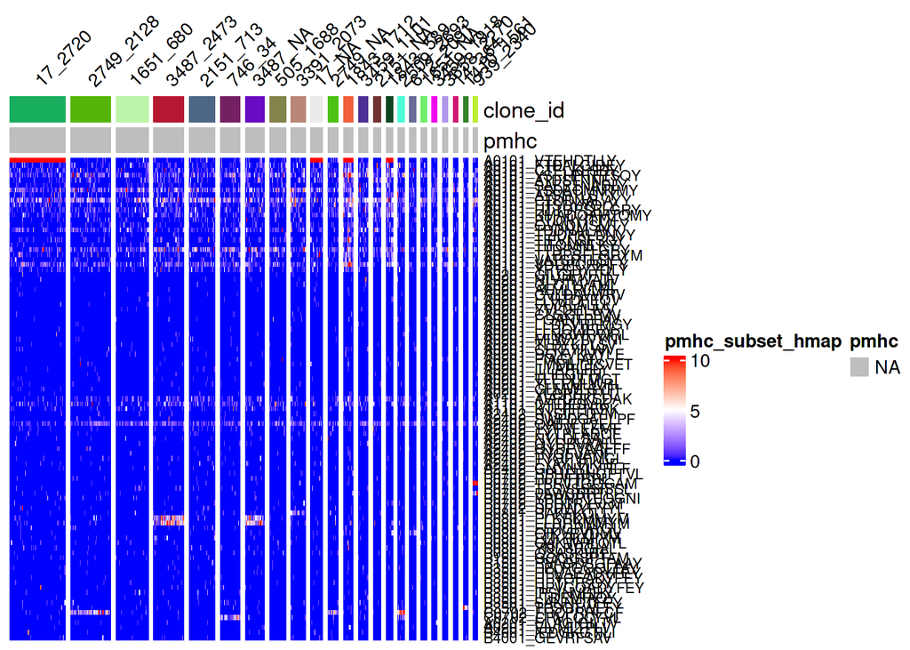

```r
# we subset gems from 1 donor for simplicity, bc=buffy coat, BC390 is a donor ID
obj_sub <- subset(viral_screen, BC == 'BC390')

# we take obly 5+ gems clviral_screen
clones <- obj_sub$clone_id[obj_sub$clone_size > 5] %>% table() %>% sort(decreasing = T) %>% names()

# and we plot the heatmap, sorted by clonotypes
pmhc_heatmap(object = obj_sub, slot = 'counts', hm_breaks = c(0, 5, 10),
             clones=clones, show_row_names = T, clean_mat = F)
```

we can see that some clone (grouped columns) have noisy, but visible consistent signals some pMHCs, we can further visualise a single clone in more details

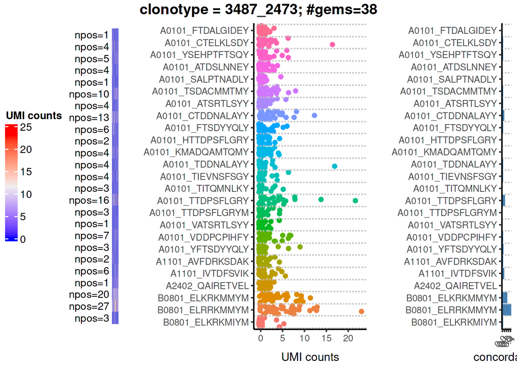

```r
pmhc_dist_per_clone(object = viral_screen, clone = '3487_2473', aggr_threshold = 10, slot = 'counts')
```

Look at this clone and pMHC counts distributions, on the left we can see that two B0801 pMHC have the highest number of gems, that aren’t zero. We can as well calculate a metric called clonal pmhc concordance, introduced in Polvsen et al 2023, elife, that calculates a proportion of gems in the clone, whose highest value of pMHC count is in this pMHC. So we can reasonably assume that this clone is B0801 specific, but data isnot clean enough to have any automate way of assigning it.

## scaling

So in next steps we can start to normalize and denoise the data, we apply speific way of mean centering and sd scaling, where means and sds are calculated, not taking outlines (|z|>3) into account. this approach is used, instead of typically used median centering and mad scaling, sinse in sparse single-cell datasets, medians and mads are often zeros.

```r
viral_screen <- ScaleDataNoOutliers(viral_screen)
```

```
## [1] "iteration 1"
## [1] "iteration 2"
## [1] "iteration 3"
## [1] "iteration 4"
## [1] "iteration 5"
```

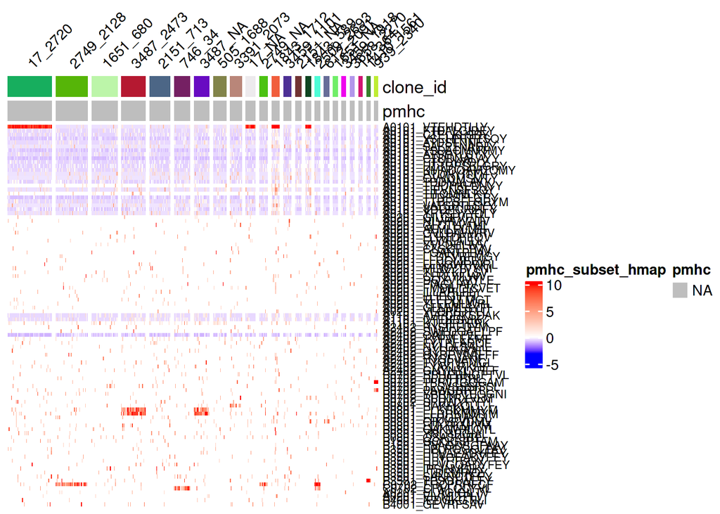

```r
obj_sub <- subset(viral_screen, BC == 'BC390')

pmhc_heatmap(object = obj_sub, slot = 'scale.data', hm_breaks = c(-3, 0, 10),
             clones = clones, show_row_names = T, clean_mat = F)
```

```r
#pmhc_dist_per_clone(object = obj_sub, clone = '3487_2473', aggr_threshold = 10, slot = 'scale.data')
```

We can clearly see more clear signal, that we can further improve in the next step, which is smoothing each pMHC within each expanded clone, using local regression (loess).

## smoothing

```r
obj_sub <- smooth_pmhc(obj_sub)
```

```
## Processing 1 of 23
## smoothing all pmhcs for clone 1843_1712
## Processing 2 of 23
## smoothing all pmhcs for clone 3487_NA
## Processing 3 of 23
## smoothing all pmhcs for clone 17_2720
## Processing 4 of 23
## smoothing all pmhcs for clone 2151_713
## Processing 5 of 23
## smoothing all pmhcs for clone 612_2091
## Processing 6 of 23
## smoothing all pmhcs for clone 746_34
## Processing 7 of 23
## smoothing all pmhcs for clone 2749_2128
## Processing 8 of 23
## smoothing all pmhcs for clone 3487_2473
## Processing 9 of 23
## smoothing all pmhcs for clone 2509_2693
## Processing 10 of 23
## smoothing all pmhcs for clone 3658_2270
## Processing 11 of 23
## smoothing all pmhcs for clone 2749_NA
## Processing 12 of 23
## smoothing all pmhcs for clone 14_364
## Processing 13 of 23
## smoothing all pmhcs for clone 17_NA
## Processing 14 of 23
## smoothing all pmhcs for clone 1651_680
## Processing 15 of 23
## smoothing all pmhcs for clone 3391_2073
## Processing 16 of 23
## smoothing all pmhcs for clone 2151_NA
## Processing 17 of 23
## smoothing all pmhcs for clone 939_2340
## Processing 18 of 23
## smoothing all pmhcs for clone 1843_589
## Processing 19 of 23
## smoothing all pmhcs for clone 1651_NA
## Processing 20 of 23
## smoothing all pmhcs for clone 3459_1918
## Processing 21 of 23
## smoothing all pmhcs for clone 1410_1561
## Processing 22 of 23
## smoothing all pmhcs for clone 3459_1101
## Processing 23 of 23
## smoothing all pmhcs for clone 505_1688
```

```r
obj_sub <- assign_pmhc(obj_sub)
```

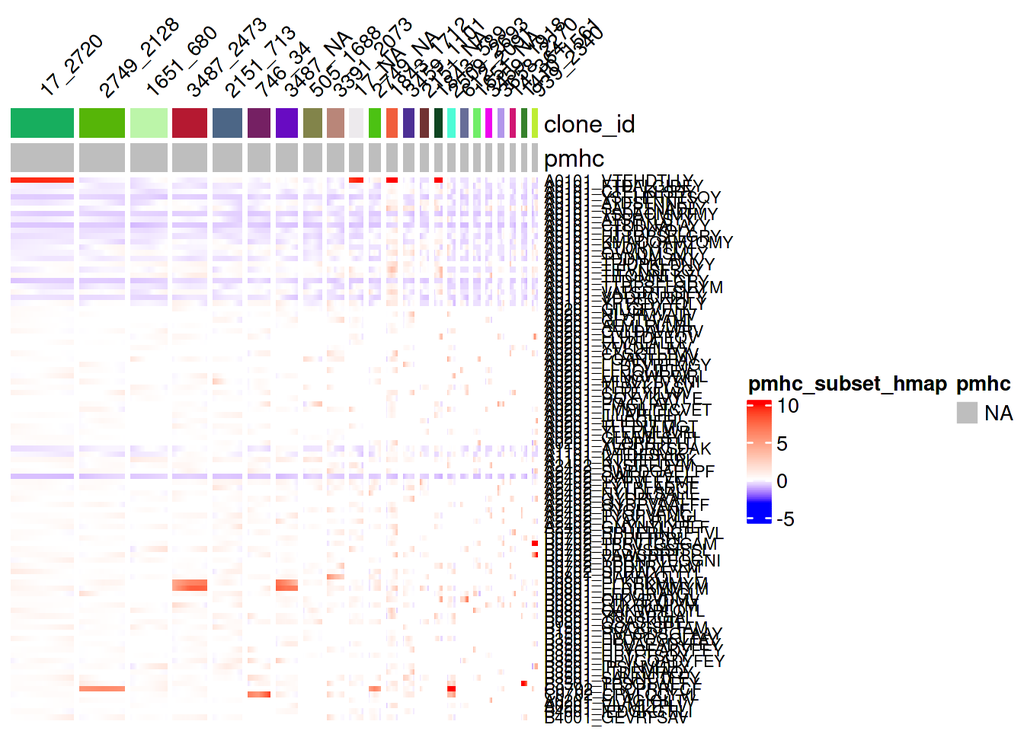

```r
pmhc_heatmap(object = obj_sub, slot = 'scale.data', hm_breaks = c(-3, 0, 10),
             clones = clones, show_row_names = T, clean_mat = F)
```

```r
#pmhc_dist_per_clone(object = obj_sub, clone = '3487_2473', aggr_threshold = 10, slot = 'scale.data')
```

this way loess regression minimises the within clone variability in the pMHC values, forcing outliers to follow the trend, thus denoising the data and making it easy to autocatically assign specificities to each clone. If clone has no signal for any pMHc in your panel, its labeled as negative. The pMHC assigments are stored in `pMHC_classification` column by default

```r
obj_sub$pMHC_classification %>% head(10)
```

```
##              1OS_AAACCTGGTAGCCTAT              1OS_AAACCTGGTATTCTCT
##                 "A0101_VTEHDTLLY" "B0801_ELKRKMMYM:B0801_ELRRKMMYM"
##              1OS_AAAGCAAAGGTGCAAC              1OS_AAAGCAACATTGGTAC
##                                NA                 "A0101_VTEHDTLLY"
##              1OS_AAAGTAGAGTCGATAA              1OS_AAATGCCGTGCAACGA
##                        "Negative"                                NA
##              1OS_AAATGCCTCAGTTGAC              1OS_AAATGCCTCCTATTCA
##                 "B0801_QIKVRVDMV"                 "C0702_CRVLCCYVL"
##              1OS_AAATGCCTCTAAGCCA              1OS_AACACGTCATGCCACG
##                        "Negative"                                NA
```